# Stageos-gitlab-howto

# 1 Principes généraux

Le site StagOs vous permet de créer des projets sur lesquels vous pourrez le cas échéant travailler à plusieurs, y compris pendant leurs phases d’exploitation et de maintenance.

Nous vous créons automatiquement et dynamiquement le pipeline qui vous permettra de gérer de bout en bout votre tégration continue et votre déploiement continu.

Une intelligence artificielle scrute vos sources lors de vos commits et en déduit les composants à intégrer dans votre *pipeline* puis déclenche celui-ci jusqu’à l’étape que vous avez déterminée, et ce le cas échéant jusqu’à la mise en exploitation automatisée de votre application via des containers sécurisés et perfomants (**Docker/Kubernetes** ) exposés via *AWS*.

Le projet est abrité sous le Gitlab StageOS et nous vous proposons donc ici un petit mode d’emploi de celui-ci dans le contexte StageOs.

# 2 S’identifier sous StageOS

Il convient tout d’abord de faire un *sign up*, vous recevrez alors un mail de confirmation.

A partir de là vous pourrez vous identifier et serait en mesure de créer vos projets.

[figure not shown]

(#fig:sign_in) écran d’identification

A tout moment vous pouvez réinitialiser votre mot de passe ou en retrouver un au travers du lien *forgot your password?* qui est diponible dans l’écra du *sign in*.

# 3 Gérer mes projets

Après vous être identifié, vous avez accès à vos projets. Notez que ce cycle sera plus rapide lors de vos prochains accès à StageOS qui vous remettra automatiquement dans votre contexte via différents mécanismes, dont le mécanisme SSL (nous verrons plus loin comment et ou déclarer votre clé RSA).

## 3.1 Créer un projet

Au départ, l’interface des projets est vide, et vous êtes incité à cliquer sur le **+** vert pour créer un nouveau projet.

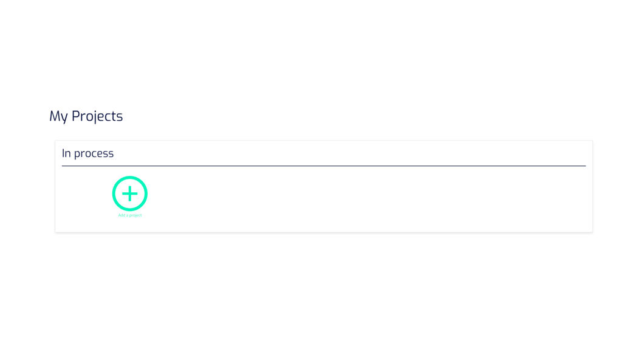

(#fig:my_project_empty) création de projets

Vous accédez alors à l’interface de création de projet. Soyez très attentif à la façon dont vous allez renseigner le nom du projet et les commentaires car cela aidera vos collègues ou partenaires à mieux cerner l’objet de celui-ci.

Vous remarquerez que vous pouvez inviter d’autres personnes à participer au projet avec divers rôles. A ce stade vous êtes encore seul et votre rôle est *mainteneur* du projet, ce qui vous donne tous les droits sur celui-ci.

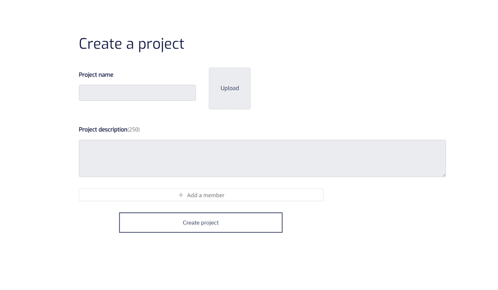

(#fig:create_project) création de projets - détail

Après un petit temps d’attente votre projet est créé. Pour ce faire nous avons configuré Gitlab avec vos crédentiels initiaux et créé les utilisateurs concernés.

Nous avons créé un projet sous Gitlab, ce qui explique qu’il soit désigné par l’icône de ce produit.

[figure not shown]

(#fig:my_projects) mes projets

Vous pouvez alors aller consulter la syntèse de votre projet en cliquant sur son icône.

[figure not shown]

(#fig:external_view_my_project) mes projets

Notez qu’à tout moment vous pouvez décider de rendre ce projet publique à la communauté StageOS et/ou le rendre à nouveau privé via le switch *public/private*.

Vous constatez que votre projet est affublé d’un mini identifiant interne à StageOs, un nombre (ici *496* ), ne soyez pas étonné!

Vous n’avez pas encore se status sur vos Pipelines, puisque vous n’avez encore rien produit ou clôné dans votre *repository* Gitlab.

Vous pouvez maintenant cliquer vers le l’url du Gitlab créé automatiquement pour vous, qui ressemble à cela :

```
  https://xxxx.stageos.io/first-project-496/first-project.git
```

**Attention** : StageOS gère votre sécurité, il vous demande donc de vous *signer* au travers de son propre mécanisme ( Bouton *Stage OS*).

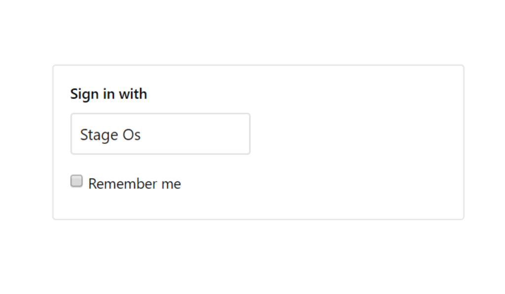

(#fig:sign_with_stageos) mes projets

Maintenant, laissez-vous faire et accédez à votre projet sous Gitlab.

Vous y êtes, force est de constater que c’est un peu vide et que personne ne vous a encore mis d’étoile ni *forké*, mais maintenant tout est possible !

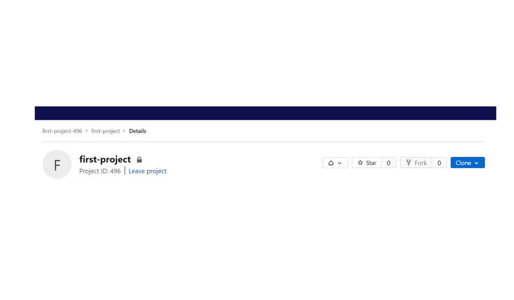

(#fig:first_project) mes projets

Pour être parfaitement opérationnel et sécurisé il vous faut **accepter** au plus vite de créer un couple de clé RSA (publiques et privées) pour mettre en place le mécanisme SSL pour gérer les habilitations entre vous, à savoir un ou plusieurs matériels, et le Gitlab. Notez que vous pouvez introduire plusieurs clés et les détruire.

Sous la ligne de commande de votre machine Linux/MAC/Windows (ou via Putty ou Kitty sous Windows, en utilisant les mêmes paramêtres) vous pouvez saisir, en y mettant votre propre adresse email:

```bash
ssh-keygen -o -t rsa -b 4096 -C "mon_adresse_mail@site.extension"
```

Il vous faut alors donner un nom de fichier ( **cela génèrera 2 fichiers**), Attention identifier bien le chemin des deux fichiers et conservez les bien à l’abris des regards !

```
Enter file in which to save the key (chemin ...) :
```

Il est conseillé d’accepter de donner une *paraphrase*, une chaine de caractère qui protège l’accès à vos clés.

Il vous suffira maintenant d’ouvir le fichier **clé publique** et de couper/coller la clé qui s’y trouve là où Gitlab vous le demande.

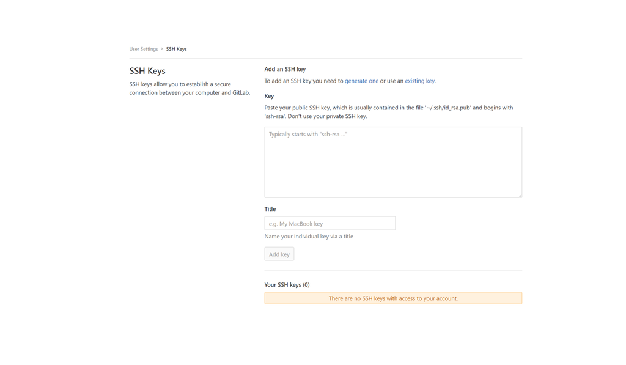

Figure 3.1: là où il faut coller sa clé publique

Voilà, après avoir cliqué sur *Add key*, vous avez fini la configuration minimale de votre projet et vous êtes opérationne !

## 3.2 Détruire un projet

Soyez très prudent avec cette action **irréversible**.

Il est évident que la plupart des développeurs travaillent sur un environnement local et effectuent régulièrement un *push* de leur environnement vers l’espace commun, ici le projet que vous venez de créer : ce qui crée une forme de sauvegarde locale de vos informations. Pour autant, la destruction du projet vous fait perdre la traçabilité des mises à jours des différents acteurs et des informations disponibles dans le *wiki* du projet (entre autres).

Il est de toute façon de bonne pratique de cloner régulièrement votre projet afin de disposer de sauvegardes logiques de celui-ci ( via les mécanismes de Git qui sont documentés dans notre interface Gitlab).

Evidemment, pour sa part, StageOS a mis en place les mécanismes de sauvegarde indispensables pour préserver votre patrimoine applicatif.

Pour détruire un projet cliquer la croix ( *x* ) rouge. Vous disposez alors d’une dernière chance de retour arrière via le bouton *Cancel*.

[figure not shown]

(#fig:delete_project) destruction projet

# 4 FAQ : Vos questions les plus fréquentes

## 4.2 Suis-je obligé d’avoir un Kubernetes à ma disposion ?

Non, mais vous pouvez en souscrire un pour déployer en production automatiquement.